# Cardio Good Fitness Project

# **Overview**

This project has 3 main parts:

1. Introduction
2. Exploratory Data Analysis
   - A) Data Structure Overview
   - B) Univariate Data Analysis
   - C) Multivariate Data Analysis
3. Conclusion

# **Introduction**

This project is about the analysis of the customers with the treadmill products at Cardio Good Fitness store. The dataset is analyzed to identify the differences of the customers for each product. In the end of the project, we would like to have key of insights and recommendations to help company to target new customers.

# **Exploratory Data Analysis**

## A. Data Structure Overview

### 1. Import the necessary packages

```python
import pandas as pd
import matplotlib.pyplot as plt
import seaborn as sns
sns.set(color_codes = True)
%matplotlib inline
plt.rc('figure', figsize = [10,6])

import warnings
warnings.filterwarnings('ignore')
pd.set_option('display.float_format', lambda x: '%.5f' % x)
```

### 2. Read the dataset

```python
cardio_data = pd.read_csv('CardioGoodFitness.csv')
```

### 3. View the first 5 rows in the dataset

```python
cardio_data.head(5)
```

|  | Product | Age | Gender | Education | MaritalStatus | Usage | Fitness | Income | Miles |
| --- | --- | --- | --- | --- | --- | --- | --- | --- | --- |
| 0 | TM195 | 18 | Male | 14 | Single | 3 | 4 | 29562 | 112 |
| 1 | TM195 | 19 | Male | 15 | Single | 2 | 3 | 31836 | 75 |
| 2 | TM195 | 19 | Female | 14 | Partnered | 4 | 3 | 30699 | 66 |
| 3 | TM195 | 19 | Male | 12 | Single | 3 | 3 | 32973 | 85 |
| 4 | TM195 | 20 | Male | 13 | Partnered | 4 | 2 | 35247 | 47 |

### 4. Overview of the data shape

```python
cardio_data.shape
```

```
(180, 9)
```

**Observation:** There are 180 rows and 9 columns in the dataset

### 5. Check the data types of all the columns in the dataset

```python
cardio_data.dtypes
```

```
Product          object
Age               int64
Gender           object
Education         int64
MaritalStatus    object
Usage             int64
Fitness           int64
Income            int64
Miles             int64
dtype: object
```

**Observation:**

1. Product, gender, and marital status are string data type.
2. Age, education, usage, fitness, income, and miles and integer data type.

### 6. Statistical summary for the dataset

```python
cardio_data.describe(include = 'all')
```

|  | Product | Age | Gender | Education | MaritalStatus | Usage | Fitness | Income | Miles |
| --- | --- | --- | --- | --- | --- | --- | --- | --- | --- |
| count | 180 | 180.00000 | 180 | 180.00000 | 180 | 180.00000 | 180.00000 | 180.00000 | 180.00000 |
| unique | 3 | nan | 2 | nan | 2 | nan | nan | nan | nan |
| top | TM195 | nan | Male | nan | Partnered | nan | nan | nan | nan |
| freq | 80 | nan | 104 | nan | 107 | nan | nan | nan | nan |
| mean | NaN | 28.78889 | NaN | 15.57222 | NaN | 3.45556 | 3.31111 | 53719.57778 | 103.19444 |
| std | NaN | 6.94350 | NaN | 1.61705 | NaN | 1.08480 | 0.95887 | 16506.68423 | 51.86360 |
| min | NaN | 18.00000 | NaN | 12.00000 | NaN | 2.00000 | 1.00000 | 29562.00000 | 21.00000 |
| 25% | NaN | 24.00000 | NaN | 14.00000 | NaN | 3.00000 | 3.00000 | 44058.75000 | 66.00000 |
| 50% | NaN | 26.00000 | NaN | 16.00000 | NaN | 3.00000 | 3.00000 | 50596.50000 | 94.00000 |
| 75% | NaN | 33.00000 | NaN | 16.00000 | NaN | 4.00000 | 4.00000 | 58668.00000 | 114.75000 |
| max | NaN | 50.00000 | NaN | 21.00000 | NaN | 7.00000 | 5.00000 | 104581.00000 | 360.00000 |

**Observation** :

1. The average age of all customers in the dataset is around 29 years old, with the minimum of age 18, and maximum of age 50.
2. The average education of all customers is 16 years, with the minimum of 12 years and maximum of 21 years.
3. The average customers' usage is around 3 times every week, while the minimum is 2 times, and maximum is 7 times a week.
4. The average of income that customers earn is \$53,719, with the minimum is \\$29,562 and maximum is \$104581.
5. The average miles that customers run in this dataset is 103 miles, while the minimum is 21 miles, and the maximum is 360 miles.

### 7. Check if the dataset has missing values

```python
cardio_data.isna().sum()
```

```
Product          0
Age              0
Gender           0
Education        0
MaritalStatus    0
Usage            0
Fitness          0
Income           0
Miles            0
dtype: int64
```

**Observation:** The dataset does not have missing values.

## B. Univariate Data Analysis

### 1. Overview of Gender variable

#### a) Count the amount of unique gender in the dataset:

```python
cardio_data['Gender'].value_counts()
```

```
Male      104
Female     76
Name: Gender, dtype: int64
```

**Observartion:** There are 104 male and 76 male in the dataset.

#### b) Find the population proportion of gender:

```python
gender_prop = cardio_data['Gender'].value_counts()
gender_prop/gender_prop.sum()
```

```
Male     0.57778
Female   0.42222
Name: Gender, dtype: float64
```

**Observation:** There are 57.78% male and 42.2% female in the dataset.

#### c) Visualization of gender variable:

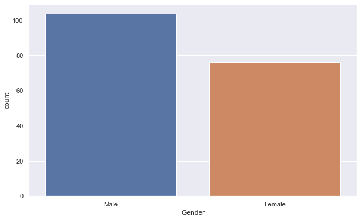

```python
sns.countplot(data = cardio_data, x = 'Gender');
```

**Observation:** The graph shows that there are more male than female in the dataset.

### 2. Overview of Product variable

#### a) Count the amount of unique product in the dataset:

```python
cardio_data['Product'].value_counts()
```

```
TM195    80
TM498    60
TM798    40
Name: Product, dtype: int64
```

**Observation:** There are 3 treadmill products in the dataset:

- TM195 with 80 counts
- TM498 with 60 counts
- TM798 with 40 counts

#### b) Find the population proportion of the products:

```python
product_prop = cardio_data['Product'].value_counts()
product_prop/product_prop.sum()
```

```
TM195   0.44444
TM498   0.33333
TM798   0.22222
Name: Product, dtype: float64
```

**Observation:** There are 44.4% of TM195 product, 33.33% of TM498, and 22.22% of TM798 product in the dataset.

#### c) Visualization of the product variable:

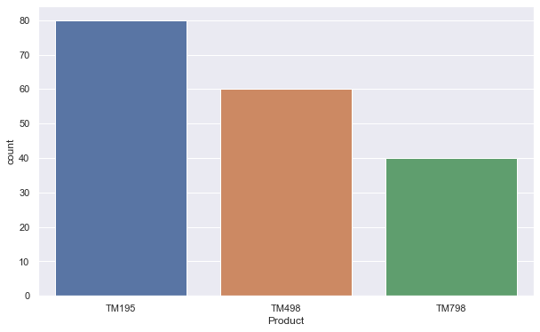

```python
sns.countplot(data = cardio_data, x = 'Product');
```

**Observation:** TM195 product has the most count in the dataset, and TM798 product has the least count.

### 3. Overview of Age variable

#### a) Summary statistics:

```python
cardio_data['Age'].describe()
```

```
count   180.00000
mean     28.78889
std       6.94350
min      18.00000
25%      24.00000
50%      26.00000
75%      33.00000
max      50.00000
Name: Age, dtype: float64
```

**Observation:** The average of age in the dataset is about 29 years old, with the minimum is 18 and maximum is 50 years old.

#### b) Visualization of age variable:

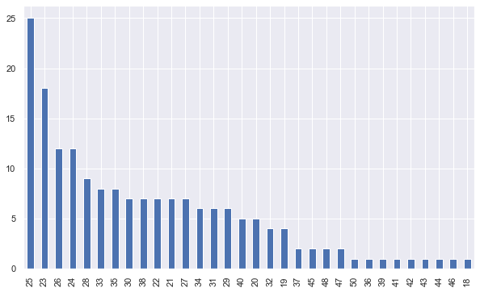

```python
cardio_data['Age'].value_counts().plot.bar();
```

**Observation:** Age of 25 has the most count in the dataset, with age of 18 has the least count.

#### c) Age variable distribution:

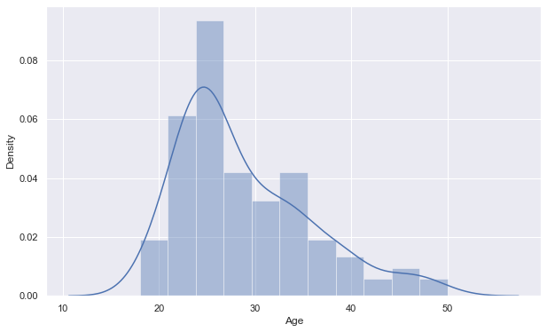

```python
sns.distplot(cardio_data['Age']);
```

**Observation:** The graph shows that the age group the has the most in the databset is around 20-30 years old, with the least is age group 40-50 years old.

### 4. Overview of Education variable

#### a. Summary statistics:

```python
cardio_data['Education'].describe()
```

```
count   180.00000
mean     15.57222
std       1.61705
min      12.00000
25%      14.00000
50%      16.00000
75%      16.00000
max      21.00000
Name: Education, dtype: float64
```

**Observation:** The average of education in the dataset is 16 years, with the minimum is 12 years, and maximum is 21 years.

#### b. Count the unique amount in the education variable:

```python
cardio_data['Education'].value_counts()
```

```
16    85
14    55
18    23
15     5
13     5
21     3
12     3
20     1
Name: Education, dtype: int64
```

**Observation:** Education of 16 years has the most count, and the least is education of 20 years.

#### c. Population proportion of education:

```python
education_prop = cardio_data['Education'].value_counts()
education_prop/education_prop.sum()
```

```
16   0.47222
14   0.30556
18   0.12778
15   0.02778
13   0.02778
21   0.01667
12   0.01667
20   0.00556
Name: Education, dtype: float64
```

**Observation:** Education of 16 years has about 47.22% in the dataset, with 0.55% for education of 20 years.

#### d. Visualization of education variable:

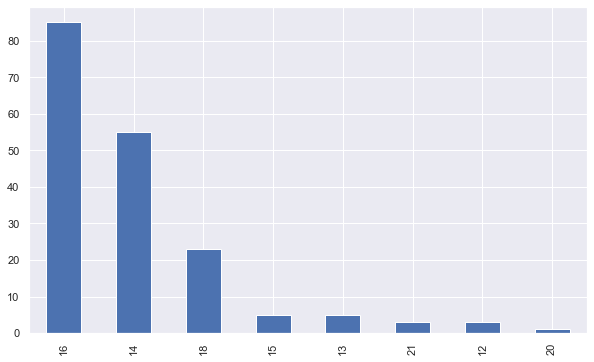

```python
cardio_data['Education'].value_counts().plot.bar();
```

**Observation:** The graph shows the education of 16 years has the most count, with the least is education of 20 years.

### 5. Overview of Marital Status variable

#### a. Count the amount of unique marital status:

```python
cardio_data['MaritalStatus'].value_counts()
```

```
Partnered    107
Single        73
Name: MaritalStatus, dtype: int64
```

**Observation:** There are 107 customers are partnered, and 73 customers are single in the dataset.

#### b. Find the population proportion of marital status:

```python
marital_prop = cardio_data['MaritalStatus'].value_counts()
marital_prop/marital_prop.sum()
```

```
Partnered   0.59444
Single      0.40556
Name: MaritalStatus, dtype: float64
```

**Observation:** There are 59.44% customers in the dataset are partnered, and 40.56% customers are single.

#### c. Visualization of marital status variable:

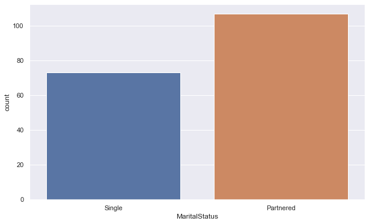

```python
sns.countplot(data = cardio_data, x = 'MaritalStatus');
```

**Observation:** The graph shows that customers that are partnered have more counts than single customers.

### 6. Overview of Usage Variable

#### a. Summary statistics:

```python
cardio_data['Usage'].describe()
```

```
count   180.00000
mean      3.45556
std       1.08480
min       2.00000
25%       3.00000
50%       3.00000
75%       4.00000
max       7.00000
Name: Usage, dtype: float64
```

**Observation:** The average of the usage in the dataset is 3.46 times, with a minimum of 2 times, and maximum is 7 times.

#### b. Count the unique amount in the usage variable:

```python
cardio_data['Usage'].value_counts()
```

```
3    69
4    52
2    33
5    17
6     7
7     2
Name: Usage, dtype: int64
```

**Observation:** The usage of 3 times has the most count with 69, and the least is 7 times with the count of 2.

#### c. Find population proportion of the usage variable:

```python
usage_prop = cardio_data['Usage'].value_counts()
usage_prop/usage_prop.sum()
```

```
3   0.38333
4   0.28889
2   0.18333
5   0.09444
6   0.03889
7   0.01111
Name: Usage, dtype: float64
```

**Observation:** There is about 38.33% that customers run 3 times every week, with the least is 1.11% that customers run 7 times every week

#### d. Visualization of usage variable:

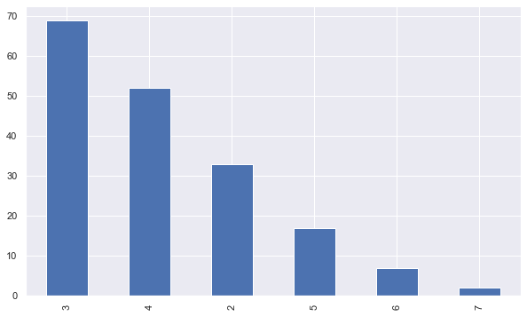

```python
cardio_data['Usage'].value_counts().plot.bar();
```

**Observation:** The graph shows that running 3 times every week has the most count, with the least is 7 times every week.

### 7. Overview of Fitness Variable

#### a. Summary statistics

```python
cardio_data['Fitness'].describe()
```

```
count   180.00000
mean      3.31111
std       0.95887
min       1.00000
25%       3.00000
50%       3.00000
75%       4.00000
max       5.00000
Name: Fitness, dtype: float64
```

**Observation:** The average fitness score from the dataset is 3.31, with the minimum is 1 and maximum is 5.

#### b. Count the unique amount of the fitness variable:

```python
cardio_data['Fitness'].value_counts()
```

```
3    97
5    31
2    26
4    24
1     2
Name: Fitness, dtype: int64
```

**Observation:** The fitness score of 3 has the most count, with the least is the score of 1.

#### c. Find population proportion of the fitness variable:

```python
fitness_prop = cardio_data['Fitness'].value_counts()
fitness_prop/fitness_prop.sum()
```

```
3   0.53889
5   0.17222
2   0.14444
4   0.13333
1   0.01111
Name: Fitness, dtype: float64
```

**Observation:** There is 53.89% of the customers have fitness score of 3, and 1.11% customers have fitness score of 1.

#### d. Visualization of fitness variable:

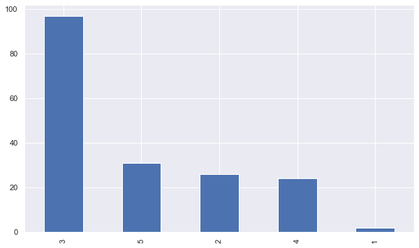

```python
cardio_data['Fitness'].value_counts().plot.bar();
```

**Observation:** The graph shows that fitness score of 3 has the most count, and the least count is 1.

### 8. Overview of income variable

#### a. Summary statistics:

```python
cardio_data['Income'].describe()
```

```
count      180.00000
mean     53719.57778
std      16506.68423
min      29562.00000
25%      44058.75000
50%      50596.50000
75%      58668.00000
max     104581.00000
Name: Income, dtype: float64
```

**Observation:** The average income in the dataset is \$53,719, with the minimum of \\$29,562 and maximum is \$104,581.

#### b. Visualization of income variable:

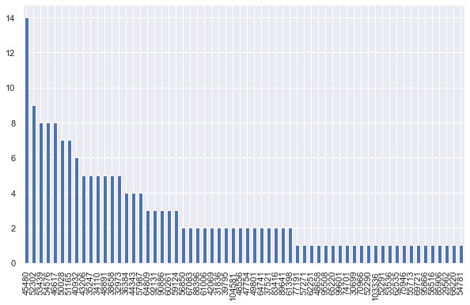

```python
cardio_data['Income'].value_counts().plot.bar();
```

**Observation:** The graph shows that the income of \$45,480 has the most count, and the least is \\$54,781.

#### c. Distribution of income variable:

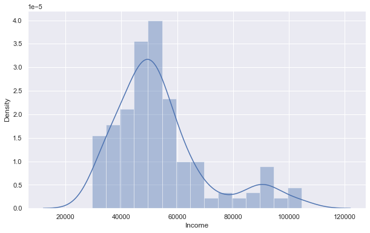

```python
sns.distplot(cardio_data['Income']);
```

**Observation:** The graph shows that most of the income of the customers has the range around \$40,000 to \\$60,000.

### 9. Overview of Miles variable

#### a. Summary statistics:

```python
cardio_data['Miles'].describe()
```

```
count   180.00000
mean    103.19444
std      51.86360
min      21.00000
25%      66.00000
50%      94.00000
75%     114.75000
max     360.00000
Name: Miles, dtype: float64
```

**Observation:** The average of miles that customers run in the dataset is 103 miles, with the minimum of 21 miles and maximum is 360 miles.

#### b. Visualization of miles avariable:

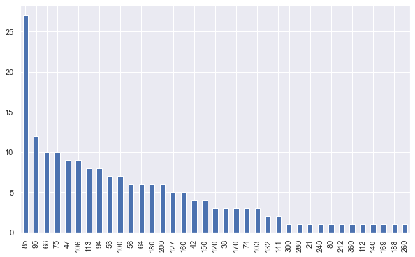

```python
cardio_data['Miles'].value_counts().plot.bar();
```

**Observation:** The graph shows that 85 miles has the most count, and the least is 260 miles.

#### c. Distribution of miles variable:

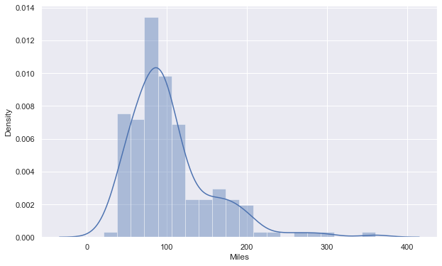

```python
sns.distplot(cardio_data['Miles']);
```

**Observation:** The graph shows that the most miles that customers expect to run have the range between 50 to 110 miles every week.

## C. Multivariate Data Analysis

### 1. Visualization of the numerical variables in the dataset using pair plot and correlation plot

This is the pair plot for numerical variables:

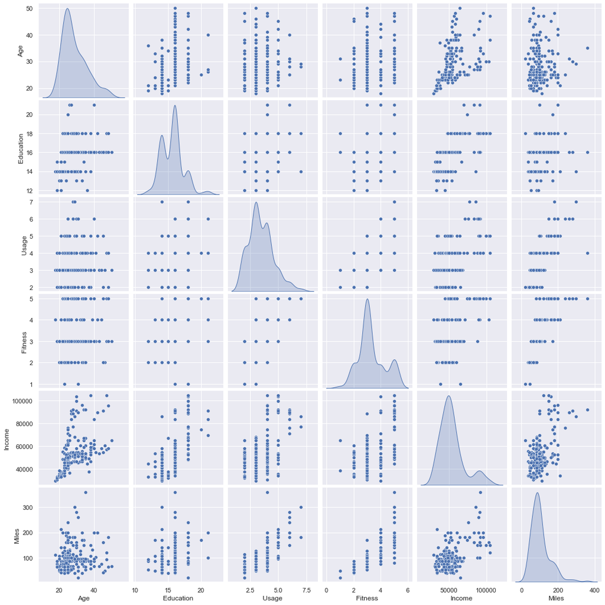

```python
sns.pairplot(cardio_data, diag_kind="kde");
```

This is 2-D matrix:

```python
correlation = cardio_data.corr()
correlation
```

|  | Age | Education | Usage | Fitness | Income | Miles |
| --- | --- | --- | --- | --- | --- | --- |
| Age | 1.00000 | 0.28050 | 0.01506 | 0.06110 | 0.51341 | 0.03662 |
| Education | 0.28050 | 1.00000 | 0.39516 | 0.41058 | 0.62583 | 0.30728 |
| Usage | 0.01506 | 0.39516 | 1.00000 | 0.66861 | 0.51954 | 0.75913 |
| Fitness | 0.06110 | 0.41058 | 0.66861 | 1.00000 | 0.53501 | 0.78570 |
| Income | 0.51341 | 0.62583 | 0.51954 | 0.53501 | 1.00000 | 0.54347 |
| Miles | 0.03662 | 0.30728 | 0.75913 | 0.78570 | 0.54347 | 1.00000 |

This is the heatmap:

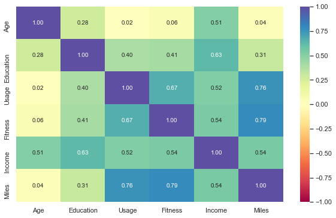

```python
sns.heatmap(correlation, annot=True, vmin=-1, vmax=1, fmt=".2f", cmap="Spectral");
```

**Observation:**

### 2. Create a new column to identify different age group

```python
cardio_data['age_group'] = pd.cut(cardio_data['Age'], [15,20,25,30,35,40,45,50])
```

```python
cardio_data['age_group'].unique()
```

```
[(15, 20], (20, 25], (25, 30], (30, 35], (35, 40], (40, 45], (45, 50]]
Categories (7, interval[int64]): [(15, 20] < (20, 25] < (25, 30] < (30, 35] < (35, 40] < (40, 45] < (45, 50]]
```

**Observation:** New age groups are created in order to visualize better. The age groups are:

- Age 15-20
- Age 20-25
- Age 25-30
- Age 30-35
- Age 35-40
- Age 40-45
- Age 45-50

### 3. Relationship between age, miles and gender

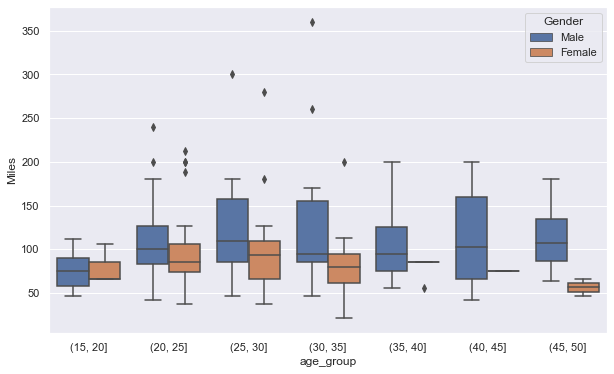

```python
sns.boxplot(data = cardio_data, x = 'age_group', y = 'Miles', hue = 'Gender');
```

**Observation:**

1. The male population in this dataset tends to run more miles than the female population.
2. In the age group between 35-40 and 40-50, a few or none of female population that run on treadmills.

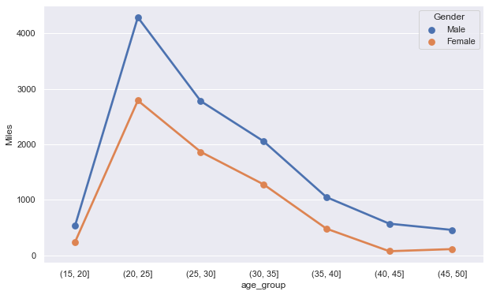

```python
sns.pointplot(x='age_group', y='Miles', data=cardio_data, estimator=sum, ci=None, hue = 'Gender');
```

**Observation:**

### 4. Relationship between age, income and gender

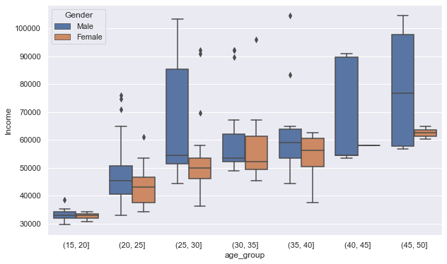

```python
sns.boxplot(data = cardio_data, x = 'age_group', y = 'Income', hue = 'Gender');
```

**Observation:** The graph shows that income that male population earns more income than female population.

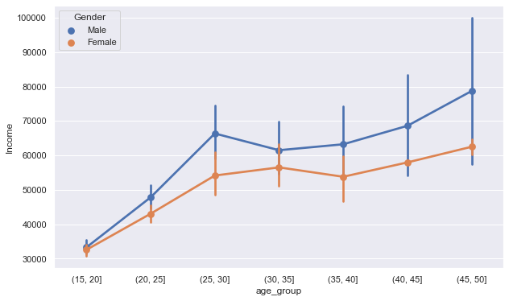

```python
sns.pointplot(data = cardio_data, x = 'age_group', y = 'Income', hue = 'Gender');
```

**Observation:** As the age increases, the income tends to increase. However, the income decreases slightly at the age group 35-40 years old.

### 5. Relationship between age, fitness and gender

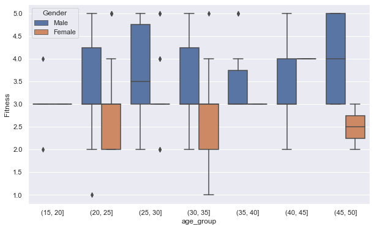

```python
sns.boxplot(data = cardio_data, x = 'age_group', y = 'Fitness', hue = 'Gender');
```

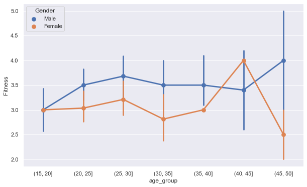

```python
sns.pointplot(data = cardio_data, x = 'age_group', y = 'Fitness', hue = 'Gender');
```

**Observation:** As expect, male population is more fit than female population. However, this graph shows that there is an increase of female population that fit around age group 40-45 years old.

### 6. Relationship between age, usage and gender

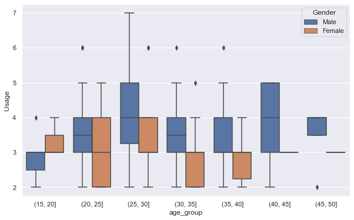

```python
sns.boxplot(data = cardio_data, x = 'age_group', y = 'Usage', hue = 'Gender');
```

**Observation:** Since previous graph shows that male population runs more, they are more likely to use the treadmill more than female.

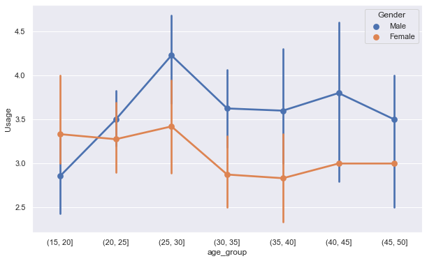

```python
sns.pointplot(data = cardio_data, x = 'age_group', y = 'Usage', hue = 'Gender');
```

**Observation:** The graph shows that age group 25-30 years old use treadmill the most in this dataset.

### 7. Relationship between age, education and gender

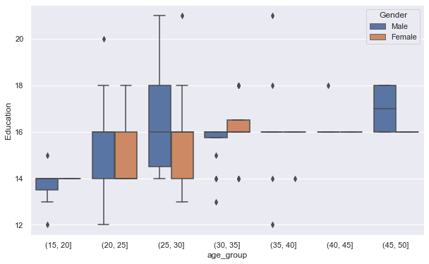

```python
sns.boxplot(data = cardio_data, x = 'age_group', y = 'Education', hue = 'Gender' );
```

**Observation:** The graph shows that male population tends to study more than female population.

### 8. Create a chart to count the total products that each age group has

```python
cardio_data.groupby('age_group')['Product'].value_counts().unstack()
```

| Product age_group | TM195 | TM498 | TM798 |
| --- | --- | --- | --- |
| (15, 20] | 6.00000 | 4.00000 | nan |
| (20, 25] | 28.00000 | 24.00000 | 17.00000 |
| (25, 30] | 21.00000 | 7.00000 | 13.00000 |
| (30, 35] | 11.00000 | 17.00000 | 4.00000 |
| (35, 40] | 8.00000 | 6.00000 | 2.00000 |
| (40, 45] | 3.00000 | 1.00000 | 2.00000 |
| (45, 50] | 3.00000 | 1.00000 | 2.00000 |

**Observation:**

1. By observing the table, we can see that the TM798 is not popular in the age group of 15-20. Hence, there is no TM798 product that owned in this age group.
2. In the age group between 20-25, maximum people have the treadmill products comparing to other age groups in this dataset.
3. In the age group of 40-50 and 45-50, people have the least treadmill products comparing to other age groups in this dataset.
4. Based on the table, as the age increases, the less people buy treadmill products.